# Risk Factor Analysis

## Outcome Variable

**Outcome Variable:** s03rec24

## Predictor Variables

**Intervention Variable:** gagebrth

**Adjustment Set:**

unadjusted

## Stratifying Variables

The analysis was stratified on these variable(s):

- studyid
- country

## Data Summary

| studyid | country | A | n | nA | nAY0 | nAY1 |
| --- | --- | --- | --- | --- | --- | --- |
| ki1000108-CMC-V-BCS-2002 | INDIA | [273-287) | 348 | 145 | 139 | 6 |
| ki1000108-CMC-V-BCS-2002 | INDIA | <259 | 348 | 47 | 42 | 5 |
| ki1000108-CMC-V-BCS-2002 | INDIA | [259-273) | 348 | 75 | 70 | 5 |
| ki1000108-CMC-V-BCS-2002 | INDIA | >=287 | 348 | 81 | 75 | 6 |
| ki1000108-IRC | INDIA | [273-287) | 390 | 165 | 149 | 16 |
| ki1000108-IRC | INDIA | <259 | 390 | 40 | 36 | 4 |
| ki1000108-IRC | INDIA | [259-273) | 390 | 92 | 83 | 9 |
| ki1000108-IRC | INDIA | >=287 | 390 | 93 | 80 | 13 |
| ki1000109-EE | PAKISTAN | [273-287) | 124 | 11 | 11 | 0 |
| ki1000109-EE | PAKISTAN | <259 | 124 | 70 | 70 | 0 |
| ki1000109-EE | PAKISTAN | [259-273) | 124 | 42 | 42 | 0 |
| ki1000109-EE | PAKISTAN | >=287 | 124 | 1 | 1 | 0 |
| ki1066203-TanzaniaChild2 | TANZANIA, UNITED REPUBLIC OF | [273-287) | 2074 | 823 | 823 | 0 |
| ki1066203-TanzaniaChild2 | TANZANIA, UNITED REPUBLIC OF | <259 | 2074 | 280 | 279 | 1 |
| ki1066203-TanzaniaChild2 | TANZANIA, UNITED REPUBLIC OF | [259-273) | 2074 | 431 | 431 | 0 |
| ki1066203-TanzaniaChild2 | TANZANIA, UNITED REPUBLIC OF | >=287 | 2074 | 540 | 540 | 0 |
| ki1101329-Keneba | GAMBIA | [273-287) | 1600 | 636 | 613 | 23 |
| ki1101329-Keneba | GAMBIA | <259 | 1600 | 165 | 149 | 16 |
| ki1101329-Keneba | GAMBIA | [259-273) | 1600 | 617 | 572 | 45 |
| ki1101329-Keneba | GAMBIA | >=287 | 1600 | 182 | 172 | 10 |
| ki1113344-GMS-Nepal | NEPAL | [273-287) | 593 | 0 | 0 | 0 |
| ki1113344-GMS-Nepal | NEPAL | <259 | 593 | 1 | 0 | 1 |
| ki1113344-GMS-Nepal | NEPAL | [259-273) | 593 | 588 | 570 | 18 |
| ki1113344-GMS-Nepal | NEPAL | >=287 | 593 | 4 | 4 | 0 |

The following strata were considered:

- studyid: ki1000108-CMC-V-BCS-2002, country: INDIA
- studyid: ki1000108-IRC, country: INDIA
- studyid: ki1000109-EE, country: PAKISTAN
- studyid: ki1066203-TanzaniaChild2, country: TANZANIA, UNITED REPUBLIC OF
- studyid: ki1101329-Keneba, country: GAMBIA
- studyid: ki1113344-GMS-Nepal, country: NEPAL

### Dropped Strata

Some strata were dropped due to rare outcomes:

## Methods Detail

We’re interested in the causal parameters $E[Y_a]$ for all values of $a \in \mathcal{A}$. These parameters represent the mean outcome if, possibly contrary to fact, we intervened to set all units to have $A=a$. Under the randomization and positivity assumptions, these are identified by the statistical parameters $\psi_a=E_W[E_{Y|A,W}(Y|A=a,W)]$. In addition, we’re interested in the mean of $Y$, $E[Y]$ under no intervention (the observed mean). We will estimate these parameters by using SuperLearner to fit the relevant likelihood factors – $E_{Y|A,W}(Y|A=a,W)$ and $p(A=a|W)$, and then updating our likelihood fit using a joint TMLE.

For unadjusted analyses ($W=\{\}$), initial likelihoods were estimated using Lrnr_glm to estimate the simple $E(Y|A)$ and Lrnr_mean to estimate $p(A)$. For adjusted analyses, a small library containing Lrnr_glmnet, Lrnr_xgboost, and Lrnr_mean was used.

Having estimated these parameters, we will then use the delta method to estimate relative risks and attributable risks relative to a prespecified baseline level of $A$.

# Results Detail

## Results Plots

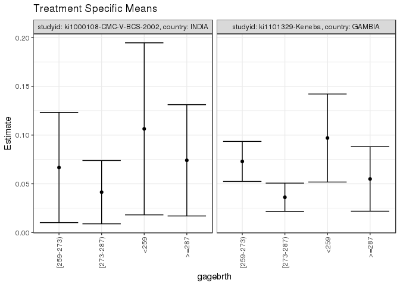

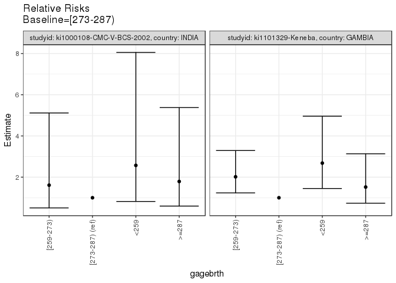

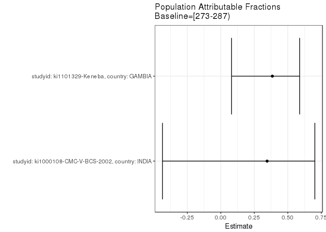

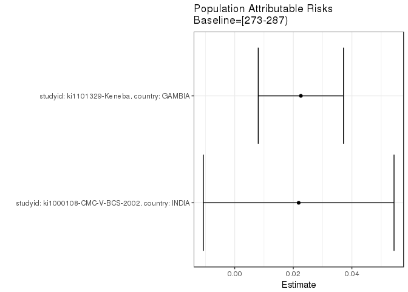

## Results Table

### Parameter: TSM

| studyid | country | intervention_level | baseline_level | estimate | ci_lower | ci_upper |
| --- | --- | --- | --- | --- | --- | --- |
| ki1000108-CMC-V-BCS-2002 | INDIA | [273-287) | NA | 0.0413793 | 0.0089152 | 0.0738435 |
| ki1000108-CMC-V-BCS-2002 | INDIA | <259 | NA | 0.1063830 | 0.0181084 | 0.1946576 |
| ki1000108-CMC-V-BCS-2002 | INDIA | [259-273) | NA | 0.0666667 | 0.0101320 | 0.1232014 |
| ki1000108-CMC-V-BCS-2002 | INDIA | >=287 | NA | 0.0740741 | 0.0169589 | 0.1311893 |
| ki1101329-Keneba | GAMBIA | [273-287) | NA | 0.0361635 | 0.0216493 | 0.0506777 |
| ki1101329-Keneba | GAMBIA | <259 | NA | 0.0969697 | 0.0518038 | 0.1421356 |
| ki1101329-Keneba | GAMBIA | [259-273) | NA | 0.0729335 | 0.0524096 | 0.0934575 |
| ki1101329-Keneba | GAMBIA | >=287 | NA | 0.0549451 | 0.0218288 | 0.0880613 |

### Parameter: E(Y)

| studyid | country | intervention_level | baseline_level | estimate | ci_lower | ci_upper |
| --- | --- | --- | --- | --- | --- | --- |
| ki1000108-CMC-V-BCS-2002 | INDIA | NA | NA | 0.0632184 | 0.0609124 | 0.0655244 |
| ki1101329-Keneba | GAMBIA | NA | NA | 0.0587500 | 0.0577305 | 0.0597695 |

### Parameter: RR

| studyid | country | intervention_level | baseline_level | estimate | ci_lower | ci_upper |
| --- | --- | --- | --- | --- | --- | --- |
| ki1000108-CMC-V-BCS-2002 | INDIA | [273-287) | [273-287) | 1.000000 | 1.0000000 | 1.000000 |
| ki1000108-CMC-V-BCS-2002 | INDIA | <259 | [273-287) | 2.570922 | 0.8206256 | 8.054390 |
| ki1000108-CMC-V-BCS-2002 | INDIA | [259-273) | [273-287) | 1.611111 | 0.5074537 | 5.115105 |
| ki1000108-CMC-V-BCS-2002 | INDIA | >=287 | [273-287) | 1.790123 | 0.5958681 | 5.377938 |
| ki1101329-Keneba | GAMBIA | [273-287) | [273-287) | 1.000000 | 1.0000000 | 1.000000 |
| ki1101329-Keneba | GAMBIA | <259 | [273-287) | 2.681423 | 1.4499217 | 4.958908 |
| ki1101329-Keneba | GAMBIA | [259-273) | [273-287) | 2.016771 | 1.2353132 | 3.292579 |
| ki1101329-Keneba | GAMBIA | >=287 | [273-287) | 1.519350 | 0.7365081 | 3.134283 |

### Parameter: PAR

| studyid | country | intervention_level | baseline_level | estimate | ci_lower | ci_upper |
| --- | --- | --- | --- | --- | --- | --- |
| ki1000108-CMC-V-BCS-2002 | INDIA | [273-287) | NA | 0.0218391 | -0.0107069 | 0.0543850 |
| ki1101329-Keneba | GAMBIA | [273-287) | NA | 0.0225865 | 0.0080365 | 0.0371364 |

### Parameter: PAF

| studyid | country | intervention_level | baseline_level | estimate | ci_lower | ci_upper |
| --- | --- | --- | --- | --- | --- | --- |
| ki1000108-CMC-V-BCS-2002 | INDIA | [273-287) | NA | 0.3454545 | -0.4356009 | 0.7015676 |
| ki1101329-Keneba | GAMBIA | [273-287) | NA | 0.3844507 | 0.0801243 | 0.5880955 |